# Alignment QC

Noelle Wheeler

2023-02-26

### 1. Which problem of mRNA-sequencing can be detected with FastQC?

- rRNA contamination  
  Yes, rRNA contamination can be detected using FastQC. The GC distribution is useful for seeing if there are any over-represented sequences which could be due to rRNA (or other) contamination. The overrepresented sequences section may show if there is rRNA contamination. The overrepresented sequences section also could help distinguish between adapter and rRNA contamination. The adapter content section might distinguish between contamination types although it is possible that fastQC did not check for the type of adapter used in the given experiment.
- mRNA degradation  
  No, you cannot detect mRNA degradation from FastQC files. mRNA degradation would be apparent post-alignment if we see any 3’/5’ bias.
- genomic DNA  
  It is difficult to detect genomic DNA from FastQC files. For this we would need post-alignment statistics. If we have a high level of non-exonic regions, especially if our library prep was poly-A enrichment, then this could indicate genomic DNA contamination.

### 2. Generate plots for assessing the read distribution across exons/introns and average gene body coverage

```
$ mamba activate qorts
$ qorts QC \
--singleEnded \
--generatePdfReport \
/home/naw4005/homework/homework3/STARalignments/ERR458500.Aligned.sortedByCoord.out.bam \
/home/luce/angsd/referenceGenomes/sacCer3.sgd.gtf \
/home/naw4005/qort_out
```

1. Read distribution across exons/introns

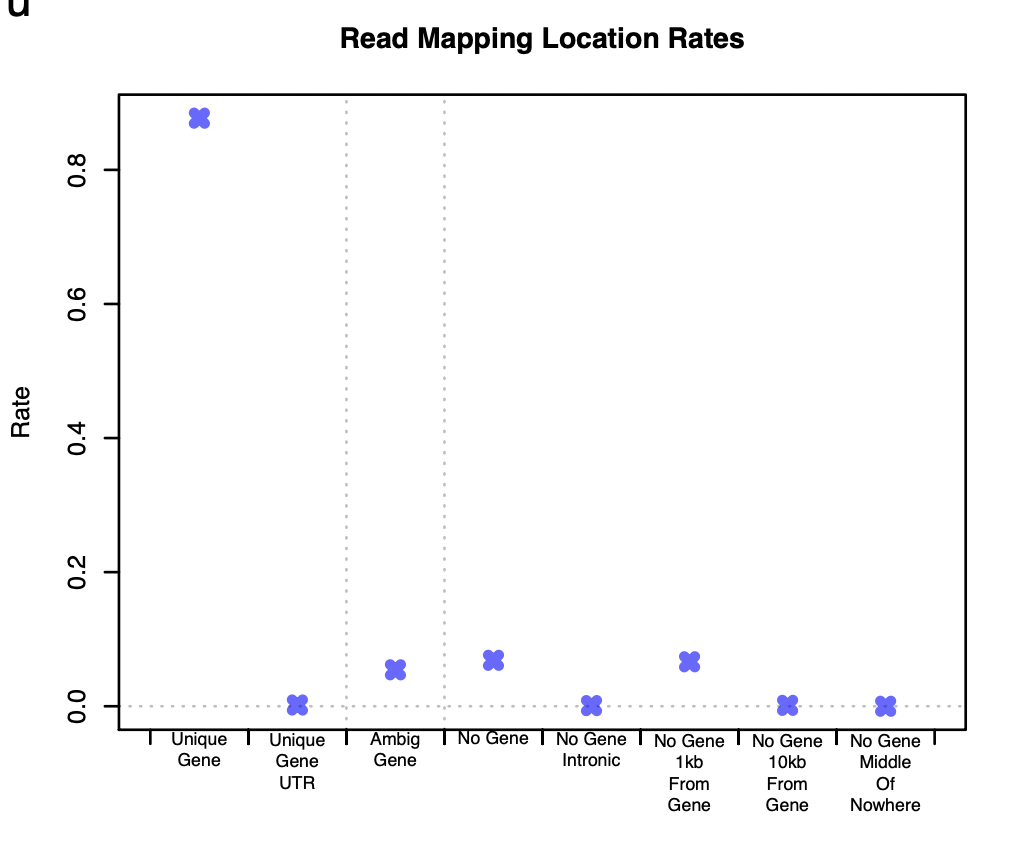

2. Average gene body coverage

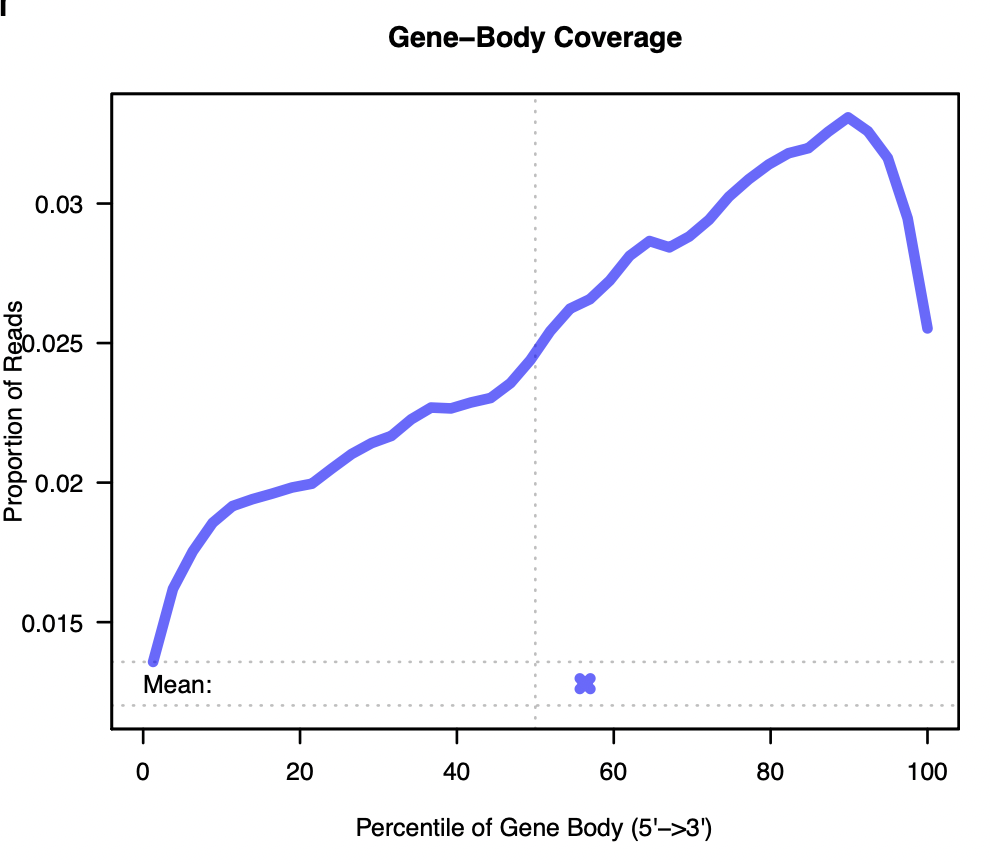

### 3. Why might a 3’ bias in the gene coverage plot be evidence of RNA degradation?

RNA would typically degrade starting at the 5’ end. This is because mRNA molecules have a 5’ cap and if this is removed then the 5’ end is vulnerable to degradation. The 3’ end has a poly-a tail which would be more resistant to degradation since it is longer.